# POP77022: Programming Exercise 1

Jack Merriman

2023-02-13

## Overview

The first homework assignment will cover concepts and methods from Weeks 1 & 2 (basic string operations, corpus acquisition, text processing, textual statistics, dictionary methods). You are expected to provide your answers as embedded R code and/or text answers in the chunks provided in the homework RMarkdown file.

For example:

```r
print("Print R code in code chunk.")
```

```
## [1] "Print R code in code chunk."
```

```
Describe results and provide answers to conceptual and open-ended questions
in a plain code block like this one.
```

**The programming exercise is worth 20% of your total grade. The questions sum to 100 points.**

## Analysis of tweets during a political crisis

We will start with a dataset that contains almost 900 tweets that were published by four central figures in American politics around the time of the onset of an impeachment inquiry: Pres. Donald Trump, Rudy Giuliani, Speaker of the House Rep. Nancy Pelosi, and Chair of the House Intelligence Committee Rep. Adam Schiff.

The first step will be to read the spreadsheet of tweets into R and then use the `str` and `head` functions to describe the variables and contents of the dataset. For your convenience, I will provide code to import the spreadsheet (*Hint: be sure that the data folder is in the same folder as this homework RMarkdown file.*)

```r
setwd(getwd())
data <- read.csv("./data/us_tweets.csv",
                 stringsAsFactors=FALSE,
                 encoding = "utf-8")
```

### Question 1.0 (2 points)

Print the number of tweets that are in this dataset.

```r
# Length of a column is number of observations
print(paste('Number of tweets:',length(data[[1]])))
```

```
## [1] "Number of tweets: 899"
```

### Question 1.1 (3 points)

Create a new dataframe that only includes original tweets (remove retweets) and print the number of rows.

```r
# tidyverse allows easier manipulation of the data frame
library(tidyverse)
data2 <- data %>%
  # subset observations that are not retweers and add them to a new data frame
  filter(is_retweet == FALSE)

# nrow another way of doing what was done in Q1.0
print(paste("Number of original tweets:",nrow(data2)))
```

```
## [1] "Number of original tweets: 662"
```

### Question 1.2 (20 points)

Create a smaller dataframe that only includes tweets by Donald Trump.

- Print how many tweets by Trump are contained in the dataset?

For the following print the number of instances as well as an example tweet:

- How many tweets include an exclamation mark?
- In how many tweets did Trump mention words related to “winning”?
- “employment”?
- “immigration”?
- “hoax”?

Make sure that you support your answers with code.

(*Hints: be sure to use regular expressions when searching the tweets; also you might want to wrap your search term in between word anchor boundaries (`\\b`). For instance, for the term health: `"\\bhealth\\b"`*)

```r
trump <- data2 %>%
   # Use Trump's twitter handle to filter his tweets
  filter(screen_name == 'realDonaldTrump')
print(paste("Number of original tweets by Donald Trump:", nrow(trump)))
```

```
## [1] "Number of original tweets by Donald Trump: 377"
```

```r
# grep returns a list of indexes of tweets containing an exclamation mark
# the length of the list is the number of tweets containing one
print(paste("Trump tweets with '!':", length(grep('\\!',trump$text))))
```

```
## [1] "Trump tweets with '!': 261"
```

```r
# use the indexes provided by the grep function to subset the tweets, then
# index the list of tweets provided to produce an example
trump$text[grep('\\!', trump$text)[1]]
```

```
## [1] "The Whistleblower, who had the facts wrong about the phone call, reached out, and more, to the Democrat controlled House Intelligence Committee. Schiff never told us about this!"
```

```r
print(paste("Trump tweets about 'winning':",
            # only  use word anchor boundaries for 'win' as the other terms
            # are unlikely to be part of unrelated words
            length(grep('winning|\\bwin\\b|winner',
                         trump$text, ignore.case = TRUE))))
```

```
## [1] "Trump tweets about 'winning': 17"
```

```r
trump$text[grep('winning|\\bwin\\b|winner',
                trump$text, ignore.case = TRUE)[1]]
```

```
## [1] "Nancy Pelosi just said that she is interested in lowering prescription drug prices &amp; working on the desperately needed USMCA. She is incapable of working on either. It is just camouflage for trying to win an election through impeachment. The Do Nothing Democrats are stuck in mud!"
```

```r
print(paste("Trump tweets about employment:",
            # 'job' is context dependent but 'jobs' is usually used in
            # macroeconomic contexts
            length(grep('employ|\\bjobs\\b',
                        trump$text, ignore.case = TRUE))))
```

```
## [1] "Trump tweets about employment: 6"
```

```r
trump$text[grep('employ|\\bjobs\\b',
                trump$text, ignore.case = TRUE)[1]]
```

```
## [1] "Breaking News: Unemployment Rate, at 3.5%, drops to a 50 YEAR LOW. Wow America, lets impeach your President (even though he did nothing wrong!)."
```

```r
print(paste("Trump tweets about immigration:",
            #second term will capture migration, immigration and emigration
            #fourth term will capture Mexico, Mexican and Mexicans
            length(grep('border|migrat|migrant|mexic|\\bwall\\b',
                        trump$text, ignore.case = TRUE))))
```

```
## [1] "Trump tweets about immigration: 21"
```

```r
trump$text[grep('border|migrat|migrant|mexic|\\bwall\\b',
                        trump$text, ignore.case = TRUE)[1]]
```

```
## [1] "Mississippi, there is a VERY important election for Governor on November 5th. I need you to Get Out and Vote for our Great Republican nominee, @TateReeves. Tate is strong on Crime, tough on Illegal Immigration, and will protect your Second Amendment...."
```

```r
print(paste("Trump tweets about hoaxes:",
            length(grep('fake news|hoax',
                        trump$text, ignore.case = TRUE))))
```

```
## [1] "Trump tweets about hoaxes: 30"
```

```r
trump$text[grep('fake news|hoax',
                trump$text, ignore.case = TRUE)[1]]
```

```
## [1] "We are simultaneously fighting the Fake News Media and their partner, the Democrat Party. Always tough to beat the “Press,” but people are beginning to see how totally CORRUPT they are, and it makes our job a whole lot easier!"
```

### Question 2 (75 points)

Create a `corpus` and a `dfm` object with processed text (including collocations) using the dataframe generated in Question 1.1. With the generated `dfm` object perform the following tasks:

1. Create a frequency plot of the top 30 tokens for each politician.
2. Determine the “key” terms that Trump and Pelosi are more likely to tweet. Plot your results
3. Perform a keyword in context analysis using your `corpus` object for some of the most distinct keywords from both Trump and Pelosi. *Hint: remember to use the `phrase` function in the `pattern` argument of `kwic`*
4. Conduct a sentiment analysis of Trump’s tweets using the Lexicon Sentiment Dictionary. Plot net sentiment over the entire sample period. Interpret the results. *Hint: you might want to use `lubridate` to generate a date object variable from the “created_at” variable before plotting. For example: `docvars(dfm, "date") <- lubridate::ymd_hms(dfm@docvars$created_at)`*
5. Justify each of your text processing decisions and interpret your results in the text field below. What can we learn about the political communication surrounding the political crisis based on the results from the above tasks?

```r
#Question 2
library(quanteda)
```

```r
library(quanteda.textstats) #collocations
library(quanteda.textplots) #Plots
library(textstem) #lemmatisation
library(lubridate)
#reset data2 variable for ease of re-running the chunk
data2 <- data %>% filter(is_retweet == FALSE)

#Remove picture tweets and tweets that are only links
#regex here finds tweets that begin with http/https and have no white-spaces
data2 <- data2[-grep('^https?\\S*$', data2$text),]
#remove columns not relevant to text analysis
data2 <- data2 %>%
  select(X, screen_name, text, created_at) %>%
  #format date
  mutate(created_at = as_datetime(created_at))
#create corpus and summary
crps <- corpus(data2, docid_field = 'X', text_field = 'text')
csum <- summary(crps, n = nrow(docvars(crps)))

#text processing
tkns <- quanteda::tokens(crps,
                         include_docvars = TRUE,
                         remove_numbers = TRUE,
                         remove_punct = TRUE,
                         remove_symbols = TRUE,
                         remove_separators = TRUE,
                         remove_url = TRUE) %>%
  tokens_tolower() %>%
  tokens_remove(stopwords("english"))
#collocations
clcs <- textstat_collocations(tkns, size = 2, min_count = 10)
#All have high Z scores and appear contextually relevant, so will be left in
tkns <- tokens_compound(tkns, clcs)
#Remove whitespaces
tkns <- tokens_remove(quanteda::tokens(tkns), "")
#Lemmatise the tokens
tkns <- as.tokens(lapply(as.list(tkns), lemmatize_words))

#Create a preliminary dfm
dfmTest <- dfm(tkns)
#Use preliminary dfm to find other stopwords and recycle code to create the final dfm
topfeatures(dfmTest, n=50)
```

```
##     president         trump           amp      democrat          make
##            85            82            77            74            67
##         great       ukraine         biden           say       country
##            67            64            59            59            54
##          good           get           now        people          call
##            53            52            51            49            49
##      election          work          know          even         never
##            43            43            41            40            40
##          time         thank           see           new       nothing
##            39            39            38            38            37
##          year          just            go        office         right
##            37            36            36            35            35
##           one        medium      congress           big      american
##            35            34            34            34            34
##            us whistleblower         house          must         wrong
##            33            33            31            30            30
##       foreign           can          want        family            do
##            30            29            29            28            28
##         china          come  conversation    republican         story
##            28            28            28            27            27
```

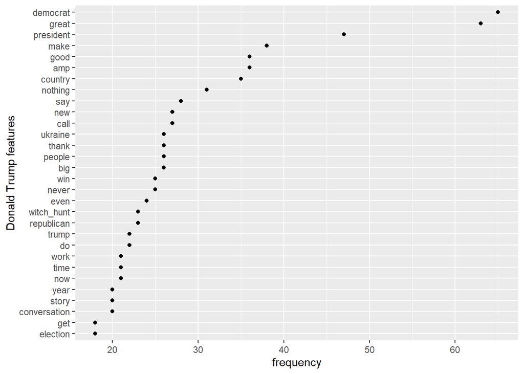

```r
extra_stopwords <- c('say', 'get', 'know', 'see', 'just', 'go', 'one', 'can', 'want', 'do', 'come')
tkns <- quanteda::tokens(crps,
                         include_docvars = TRUE,
                         remove_numbers = TRUE,
                         remove_punct = TRUE,
                         remove_symbols = TRUE,
                         remove_separators = TRUE,
                         remove_url = TRUE) %>%
  tokens_tolower() %>%
  tokens_remove(c(stopwords("english"), extra_stopwords))
tkns <- tokens_compound(tkns, clcs)
tkns <- tokens_remove(quanteda::tokens(tkns), "")
tkns <- as.tokens(lapply(as.list(tkns), lemmatize_words))
dfmTwt <- dfm(tkns)

#add in relevant docvars for analysis of the dfm
dfmTwt$author <- data2$screen_name
dfmTwt$date <- data2$created_at


#Question 2.1
#Assign frequency to objects to be plotted
frqT <- textstat_frequency(dfm_subset(dfmTwt, dfmTwt$author == 'realDonaldTrump'), n = 30)
frqP <- textstat_frequency(dfm_subset(dfmTwt, dfmTwt$author == 'SpeakerPelosi'), n = 30)
frqG <- textstat_frequency(dfm_subset(dfmTwt, dfmTwt$author == 'RudyGiuliani'), n = 30)
frqS <- textstat_frequency(dfm_subset(dfmTwt, dfmTwt$author == 'RepAdamSchiff'), n = 30)

#Create plots
frqT %>%
  ggplot(aes(x = reorder(feature, frequency), y = frequency)) +
  geom_point() +
  coord_flip() +
  labs(x = "Donald Trump features")
```

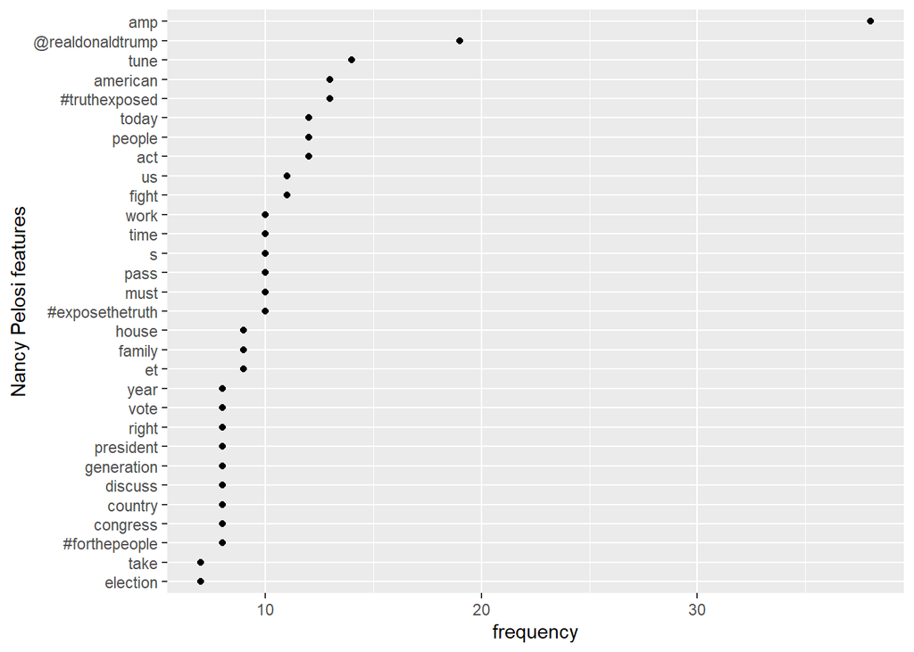

```r
frqP %>%
  ggplot(aes(x = reorder(feature, frequency), y = frequency)) +
  geom_point() +
  coord_flip() +
  labs(x = "Nancy Pelosi features")
```

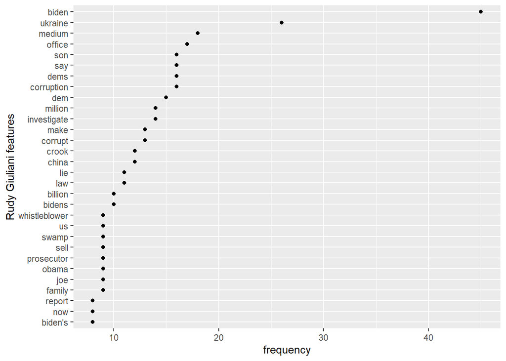

```r
frqG %>%
  ggplot(aes(x = reorder(feature, frequency), y = frequency)) +
  geom_point() +
  coord_flip() +
  labs(x = "Rudy Giuliani features")
```

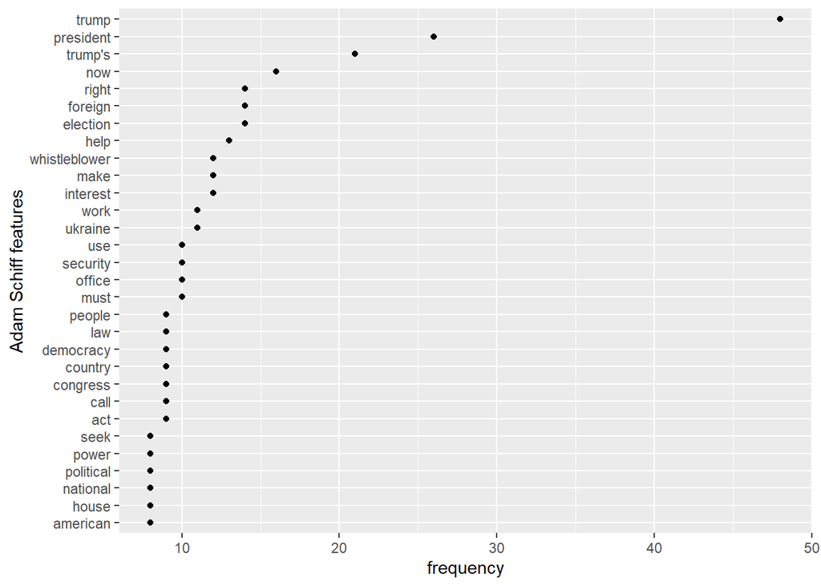

```r
frqS %>%
  ggplot(aes(x = reorder(feature, frequency), y = frequency)) +
  geom_point() +
  coord_flip() +
  labs(x = "Adam Schiff features")
```

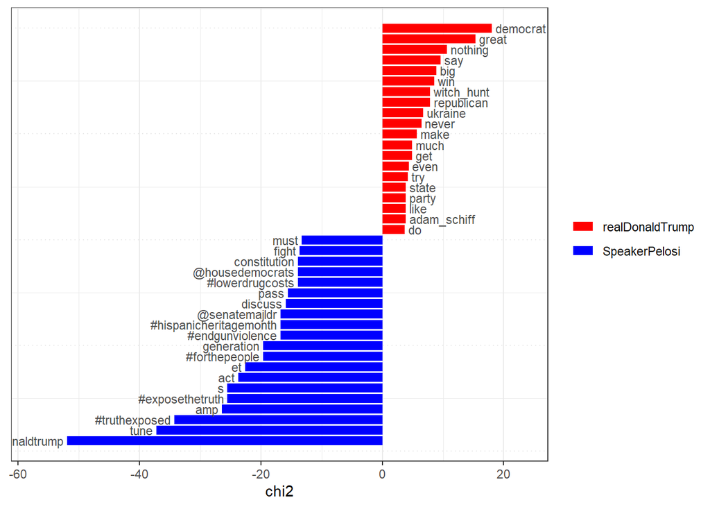

```r
#Question 2.2
#Create a subsetted dfm containing only features from Trump and Pelosi tweets
sbst <- dfm_subset(dfmTwt,dfmTwt$author == 'realDonaldTrump'|dfmTwt$author == 'SpeakerPelosi')
#Group by author for the relative keyness plot
dfmGroups <- dfm_group(sbst,fill = TRUE, groups = sbst$author)
#Find the keyness and then plot it
key <- textstat_keyness(dfmGroups, target = 'realDonaldTrump')
textplot_keyness(key, color = c('red','blue'), labelsize = 3)
```

```r
#Question 2.3
#Use the top two keywords in our analysis and find ten examples by subsetting the kwic call
kwic(crps[data2$screen_name=='realDonaldTrump'], phrase(c('great', 'democrat')), valuetype = 'glob')[1:10]
```

```
## Keyword-in-context with 10 matches.
##  [302, 22]               and more, to the | Democrat |
##  [305, 14]           ' massive hole' into | Democrat |
##  [311, 14]         and their partner, the | Democrat |
##   [312, 1]                                |  Great   |
##  [322, 11]             Florida, it was my |  great   |
##  [328, 17]           President. This is a | Democrat |
##   [329, 1]                                |  Great   |
##  [345, 14] in unfairness to a potentially |  great   |
##   [347, 2]                              A |  great   |
##   [351, 1]                                |  Great   |
##
##  controlled House Intelligence Committee.
##  accusations. Republicans at hearing
##  Party. Always tough to
##  job Jim! https://t.co/JMuE3pRWmk
##  honor to sign an Executive
##  Scam!
##  time at The Villages in
##  Justice! https://t.co/i6GwghuEsU
##  book by a brilliant author
##  job Richard! https://t.co/Uv8xgZPshu
```

```r
kwic(crps[data2$screen_name=='SpeakerPelosi'], phrase(c('tune', '@realdonaldtrump')), valuetype = 'glob')[1:10]
```

```
## Keyword-in-context with 10 matches.
##  [100, 14]    to defend the Constitution as | @realDonaldTrump |
##   [101, 3]                         What did | @realDonaldTrump |
##   [106, 4]                      Once again, | @realDonaldTrump |
##   [107, 4]                       Be sure to |       tune       |
##   [109, 9]           events makes it clear: | @realDonaldTrump |
##  [110, 23]              a joyful thing. Yet | @realDonaldTrump |
##  [111, 12]       learned a great deal about | @realDonaldTrump |
##   [112, 1]                                  |       Tune       |
##  [112, 30] House continues its inquiry into | @realDonaldTrump |
##   [115, 2]                                . | @realDonaldTrump |
##
##  ignores the Founders' warnings
##  promise China in exchange for
##  has called on a foreign
##  in to watch my full
##  personally delayed delivery of critical
##  ' s behavior leaves us
##  ' s abuses of power
##  in at 10: 45
##  ' s abuses of power
##  & amp; Admin officials
```

[figure not shown]

[output not shown]

```r
#Question 2.4
#Create a dfm of just Trump tweets to tidy code
dfmTrump <- dfm_subset(dfmTwt,dfmTwt$author == 'realDonaldTrump')
#Compile sentiment, only the first two terms from LSD to make an easy net sentiment analysis, then group by date
sntmnt <- dfm_lookup(dfmTrump, data_dictionary_LSD2015[1:2]) %>% dfm_group(groups = date)
#Calculate proportional positive and negative sentiment by date, then subtract the latter from the former to calculate net sentiment
docvars(sntmnt, "prop_negative") <- as.numeric(sntmnt[,1] / ntoken(sntmnt))
docvars(sntmnt, "prop_positive") <- as.numeric(sntmnt[,2] / ntoken(sntmnt))
docvars(sntmnt, "net_sentiment") <- docvars(sntmnt, "prop_positive") -docvars(sntmnt,"prop_negative")
#Plot the sentiment to guide our analysis
docvars(sntmnt) %>%
  ggplot(aes(x = date, y = net_sentiment, group = year(date))) +
  geom_smooth(aes(color='red')) +
  labs(title = "Sentiment of Donald Trump's tweets over time",
       x = "day of year", y = "net sentiment", colour = "year")
```